Assignment 2 · Convolution

# Training Sample Size and the Choice of Convnet: From Scratch vs. Pretrained VGG16 on Cats vs. Dogs

Python · TensorFlow 2.20.0 / Keras 3.13.2 · Kaggle notebook, 2× NVIDIA Tesla T4 · Seed 123

## 1. Executive summary

**Main finding.** The less labeled data you have, the more a pretrained network helps. Fine-tuned VGG16 scores **96.6%** on the test set with 1,000 training images, while a convnet trained from scratch scores **73.4%** — a gap of 23.2 points. The gap shrinks to 7.8 points at 5,000 images and 4.6 points at 10,000, because the scratch model keeps improving with more data while the pretrained model is already near its ceiling.

- **From scratch (Q1–Q3).** Accuracy rises steadily with sample size: test accuracy 73.4% (1,000) → 88.6% (5,000) → 93.0% (10,000) → 93.4% (20,000). The best validation accuracy is at **n = 20,000 (95.2%)**, but 10,000 images already give almost the same test accuracy.
- **Pretrained (Q4).** Accuracy is high at every size tested: 96.0%–97.6% on test and 97.6%–99.4% on validation from 500 to 10,000 images. Differences between pretrained configurations are small relative to the measurement noise.
- **Relationship.** Pretrained features substitute for labeled data. Below roughly 5,000 images, a pretrained network is clearly the better choice; from scratch, 90% validation accuracy needed at least 10,000 images.
- **Rubric target (90–100% validation accuracy).** Met by every pretrained run and by scratch at n ≥ 10,000; scratch Q1 (79.2%) and Q2 (88.0%) are below it, which is part of the finding.

| Step | Approach | n (train) | Validation | Test |
| --- | --- | --- | --- | --- |
| Q1 | From scratch | 1,000 | 79.2% | 73.4% |
| Q2 | From scratch | 5,000 | 88.0% | 88.6% |
| Q3 | From scratch (best by validation) | 20,000 | 95.2% | 93.4% |
| Q3 | From scratch (best value for effort) | 10,000 | 93.0% | 93.0% |
| Q4 / Q1 | Pretrained VGG16, fine-tuned | 1,000 | 99.4% | 96.6% |
| Q4 / Q2 | Pretrained VGG16, fine-tuned | 5,000 | 99.0% | 96.4% |
| Q4 / Q3 | Pretrained VGG16, fine-tuned | 10,000 | 99.2% | 97.6% |
| Q4 / Q3 | Pretrained VGG16, feature extraction | 10,000 | 99.2% | 97.4% |

Validation accuracy was used for early stopping and for choosing the best configuration, so it is slightly optimistic. Test accuracy (500 images never used for any decision) is the unbiased estimate. Pretrained rows are the final (fine-tuned) stage unless marked feature extraction.

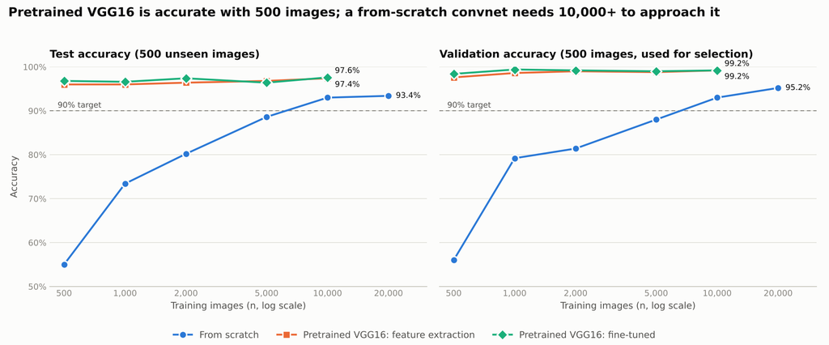

**Figure 1.** **Summary graph.** Test accuracy (left) and validation accuracy (right) against training sample size for the three approaches. The dashed line marks 90%. Pretrained VGG16 is above 96% test accuracy from 500 images; the from-scratch network passes 90% only from 10,000 images.

## 2. Objective and approach

The assignment asks how the number of training images affects the choice between training a convolutional network from scratch and reusing a pretrained one, using the Cats vs. Dogs problem. Five steps were carried out:

1. **Q1.** Train from scratch on 1,000 images (validation 500, test 500) with techniques to reduce overfitting.
2. **Q2.** Increase the training size (5,000 images) with the same validation and test sets, and re-optimize.
3. **Q3.** Sweep further sample sizes (500, 2,000, 10,000, 20,000) to find the size that gives the best results.
4. **Q4.** Repeat Q1–Q3 with a pretrained network (VGG16, sizes 500, 1,000, 2,000, 5,000, 10,000).
5. **Report.** Summarize the findings and the relationship between sample size and choice of network (this document).

## 3. Data and experimental design

The Kaggle *Dogs vs. Cats* training archive contains 25,000 labeled images (12,500 per class), labeled from the file name. To make results at different sample sizes directly comparable, the evaluation sets are fixed and shared by every experiment.

| Set | Cats | Dogs | Total | Role |
| --- | --- | --- | --- | --- |
| Validation | 250 | 250 | 500 | Early stopping, model selection |
| Test | 250 | 250 | 500 | Final unbiased estimate; never used for decisions |
| Training pool | 12,000 | 12,000 | 24,000 | Source of nested training subsets (n/2 cats + n/2 dogs) |

- **Fixed evaluation sets.** Images of each class were shuffled once (seed 123); the first 250 per class form the validation set, the next 250 the test set. Every model, at every n, is scored on the same 500 + 500 images.
- **Nested, balanced training subsets.** For a training size n, n/2 cats and n/2 dogs are taken from the pool. Smaller subsets are contained in larger ones, so the only change between runs is the amount of data.
- **Preprocessing.** Images resized to 180×180, batch size 32, binary labels (cat = 0, dog = 1).
- **Selection rule.** The best configuration is chosen by validation accuracy (the rubric’s criterion); test accuracy is reported alongside as the unbiased figure.

## 4. Models and training setup

### 4.1 Techniques to reduce overfitting (both networks)

- **Data augmentation** inside the model: random horizontal flip, rotation (±0.1 of a full turn) and zoom (±20%). Active only during training.
- **Dropout** of 0.5 before the output layer (scratch) or after the dense layer (VGG16).
- **Early stopping** on validation loss with restoration of the best weights.
- **Learning-rate reduction** (×0.5) when validation loss stops improving for 3 epochs.

### 4.2 Network trained from scratch

A small convnet of five convolution layers (32, 64, 128, 256 and 256 filters, 3×3, ReLU), the first four followed by 2×2 max-pooling, then flatten, dropout and a single sigmoid unit: **991,041 trainable parameters**. The same architecture and hyperparameters are used at every sample size.

| Layer | Output shape | Parameters |
| --- | --- | --- |
| input_layer | (180, 180, 3) | 0 |
| sequential (flip, rotation 0.1, zoom 0.2) | (180, 180, 3) | 0 |
| rescaling (1/255) | (180, 180, 3) | 0 |
| conv2d + max-pool | (89, 89, 32) | 896 |
| conv2d + max-pool | (43, 43, 64) | 18,496 |
| conv2d + max-pool | (20, 20, 128) | 73,856 |
| conv2d + max-pool | (9, 9, 256) | 295,168 |
| conv2d (no pool) | (7, 7, 256) | 590,080 |
| flatten | (12544) | 0 |
| dropout 0.5 | (12544) | 0 |
| dense, sigmoid | (1) | 12,545 |

### 4.3 Pretrained network (transfer learning)

VGG16 with ImageNet weights and no classifier head, followed by Flatten → Dense(256, ReLU) → Dropout(0.5) → Dense(1, sigmoid). Training happens in two stages: **(1) feature extraction** — the convolutional base is frozen and only the new head learns; **(2) fine-tuning** — the last convolutional block (`block5`) is unfrozen and trained with a ten-times smaller learning rate.

| Setting | From scratch | VGG16 stage 1 | VGG16 stage 2 |
| --- | --- | --- | --- |
| What trains | All layers | New dense head only | Head + block5 (last conv block) |
| Optimizer, learning rate | Adam, 1e-3 | RMSprop, 1e-4 | RMSprop, 1e-5 |
| Early stopping (val loss) | patience 10 | patience 4 | patience 4 |
| LR reduction on plateau | ×0.5 after 3 epochs | ×0.5 after 3 epochs | ×0.5 after 3 epochs |
| Max epochs | 60 (n ≤ 2,000), 50 (5,000), 40 (10,000), 30 (20,000) | 15 (Q1, Q2), 12 (sweep) | 10 (Q1, Q2), 8 (sweep) |
| Augmentation | flip, rotation 0.1, zoom 0.2 | same | same |
| Dropout | 0.5 before output | 0.5 after Dense(256) | same |
| Input scaling | ÷ 255 | VGG16 preprocess_input | same |

## 5. Results: network trained from scratch (Q1–Q3)

### 5.1 Q1: 1,000 training images

With 1,000 images the network reached **79.2% validation / 73.4% test** accuracy (best weights from epoch 44 of 54). Even with augmentation and dropout, training accuracy ran ahead of validation accuracy (Figure 2, n = 1,000) and the validation curve was noisy, the classic small-data picture.

### 5.2 Q2: 5,000 training images

Increasing the training set fivefold and re-setting the epoch budget lifted accuracy to **88.0% validation / 88.6% test**: +8.8 points on validation and +15.2 on test relative to Q1. The run used its full 50-epoch budget and was still improving slowly, so further training could add a little.

### 5.3 Q3: finding the best sample size

Running the same pipeline at 500, 2,000, 10,000 and 20,000 images shows a clear, monotonic effect of sample size (Table 1, Figure 1). Accuracy improves quickly up to 5,000–10,000 images and then flattens: from 10,000 to 20,000 images, test accuracy moves from 93.0% to 93.4% while validation accuracy moves from 93.0% to 95.2%. The best from-scratch result by validation is **n = 20,000**; 10,000 images deliver nearly the same test accuracy with half the data. Two caveats: the 10,000 and 20,000 runs ended at their epoch caps (40 and 30) while still gaining slightly, and the 500-image run never left the near-chance plateau (the network was stopped after 30 epochs with 56.0% validation accuracy).

Table 1. From-scratch results (Q1–Q3)

| n | Question | Epochs run | Restored epoch | Stopped by | Val acc | Test acc | Test 95% CI (%) | Minutes |
| --- | --- | --- | --- | --- | --- | --- | --- | --- |
| 500 | Q3 | 30 | 20 | early stop | 56.0% | 55.0% | 50.6–59.3 | 0.5 |
| 1,000 | Q1 | 54 | 44 | early stop | 79.2% | 73.4% | 69.4–77.1 | 1.5 |
| 2,000 | Q3 | 59 | 49 | early stop | 81.4% | 80.2% | 76.5–83.5 | 2.7 |
| 5,000 | Q2 | 50 | 49 | epoch cap | 88.0% | 88.6% | 85.5–91.1 | 5.2 |
| 10,000 | Q3 | 40 | 35 | epoch cap | 93.0% | 93.0% | 90.4–94.9 | 8.1 |
| 20,000 | Q3 | 30 | 29 | epoch cap | 95.2% | 93.4% | 90.9–95.3 | 11.8 |

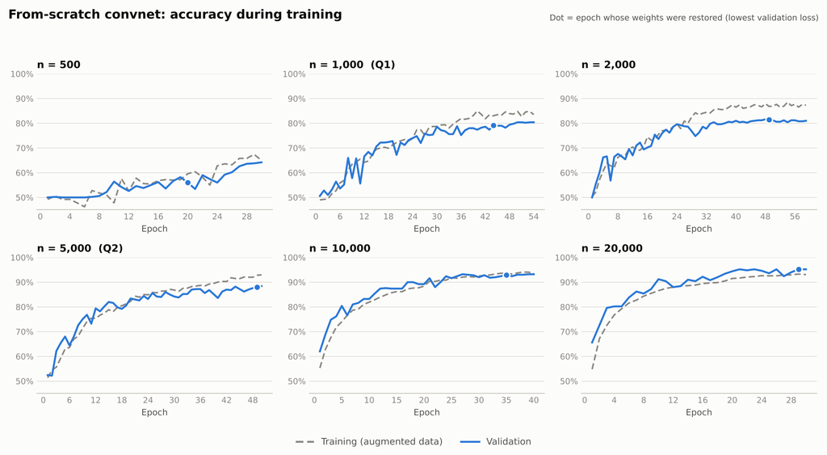

**Figure 2.** **Accuracy during training, from-scratch network.** One panel per training size (Q1 = 1,000, Q2 = 5,000). Training accuracy is measured on augmented images. The training–validation separation seen at 1,000–5,000 images disappears at 10,000–20,000.

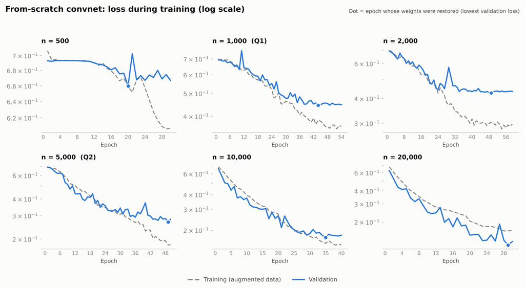

**Figure 3.** **Loss during training, from-scratch network** (log scale). Validation loss is what early stopping monitors; the dot shows the epoch whose weights were restored.

## 6. Results: pretrained VGG16 (Q4)

### 6.1 Q1 setting: 1,000 training images

Feature extraction alone reached **98.6% validation / 96.0% test**; fine-tuning `block5` raised this to **99.4% / 96.6%**. Validation accuracy was already above 95% after the first epoch of stage 1 (Figure 4).

### 6.2 Q2 setting: 5,000 training images

With five times more data, results were essentially unchanged: feature extraction 98.8% / 96.8%, fine-tuned 99.0% / 96.4%. Extra data helped little because the pretrained features were already sufficient for this task; the slight fall in fine-tuned test accuracy (−0.4 points versus feature extraction, two images out of 500) is noise.

### 6.3 Q3 setting: other sample sizes

Sizes of 500, 2,000 and 10,000 images were added (the assignment allows different sizes from the scratch network). Test accuracy ranged only from 96.0% to 97.6%. Compared with the Q1 and Q2 settings of the same method, feature extraction at 10,000 images is better on both validation (99.2% vs 98.6% and 98.8%) and test (97.4% vs 96.0% and 96.8%). Fine-tuned at 10,000 images is best on test (97.6%) but not on validation (the Q1 setting has 99.4% vs 99.2%). By validation, **fine-tuned n = 1,000** is the best pretrained configuration; by test, **fine-tuned n = 10,000**. All of these differences are within the sampling noise of a 500-image test set (Section 8), so the practical conclusion is that the pretrained network needs only a small sample: 500 to 1,000 images are enough for about 96–97% test accuracy.

“Restored epoch” is the epoch with the lowest validation loss, whose weights were restored; for VGG16 it is counted within each stage. “Stopped by” compares epochs run with the epoch cap (Section 4.3).

Table 2. Pretrained VGG16, stage 1: feature extraction

| n | Question | Epochs run | Restored epoch | Stopped by | Val acc | Test acc | Test 95% CI (%) | Minutes |
| --- | --- | --- | --- | --- | --- | --- | --- | --- |
| 500 | Q3 | 9 | 5 | early stop | 97.6% | 96.0% | 93.9–97.4 | 0.5 |
| 1,000 | Q1 | 15 | 15 | epoch cap | 98.6% | 96.0% | 93.9–97.4 | 1.3 |
| 2,000 | Q3 | 11 | 7 | early stop | 99.0% | 96.4% | 94.4–97.7 | 1.4 |
| 5,000 | Q2 | 13 | 9 | early stop | 98.8% | 96.8% | 94.9–98.0 | 3.6 |
| 10,000 | Q3 | 12 | 9 | epoch cap | 99.2% | 97.4% | 95.6–98.5 | 6.3 |

Table 3. Pretrained VGG16, stage 2: fine-tuning

| n | Question | Epochs run | Restored epoch | Stopped by | Val acc | Test acc | Test 95% CI (%) | Minutes |
| --- | --- | --- | --- | --- | --- | --- | --- | --- |
| 500 | Q3 | 8 | 7 | epoch cap | 98.4% | 96.8% | 94.9–98.0 | 0.5 |
| 1,000 | Q1 | 10 | 8 | epoch cap | 99.4% | 96.6% | 94.6–97.9 | 0.9 |
| 2,000 | Q3 | 8 | 8 | epoch cap | 99.2% | 97.4% | 95.6–98.5 | 1.2 |
| 5,000 | Q2 | 7 | 3 | early stop | 99.0% | 96.4% | 94.4–97.7 | 2.3 |
| 10,000 | Q3 | 7 | 3 | early stop | 99.2% | 97.6% | 95.9–98.6 | 4.3 |

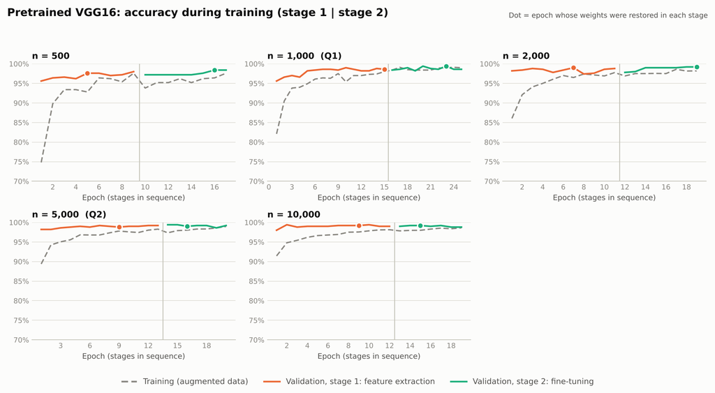

**Figure 4.** **Accuracy during training, pretrained VGG16.** Each panel shows stage 1 (feature extraction, orange validation line) followed by stage 2 (fine-tuning, green). The vertical line marks the switch. Validation accuracy starts above 95% almost immediately.

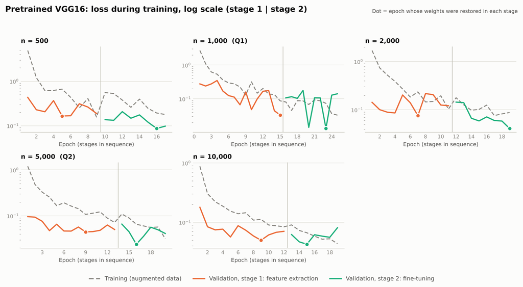

**Figure 5.** **Loss during training, pretrained VGG16** (log scale). Stage 2 lowers the best validation loss at every size (for example 0.033 → 0.013 at n = 1,000); its curve is jumpier at small n because the unfrozen block has millions of parameters and only a few hundred images to learn from.

## 7. Sample size vs. choice of network

Table 4 and Figure 6 compare the best pretrained variant (fine-tuned) with the scratch network at the same training size.

| n | Scratch test | Fine-tuned VGG16 test | Gap (points) | Validation gap (points) |
| --- | --- | --- | --- | --- |
| 500 | 55.0% | 96.8% | +41.8 | +42.4 |
| 1,000 | 73.4% | 96.6% | +23.2 | +20.2 |
| 2,000 | 80.2% | 97.4% | +17.2 | +17.8 |
| 5,000 | 88.6% | 96.4% | +7.8 | +11.0 |
| 10,000 | 93.0% | 97.6% | +4.6 | +6.2 |

Table 4. Test and validation accuracy, fine-tuned VGG16 minus from-scratch, at matched n. The n = 500 gap is inflated because the scratch network never trained properly at that size.

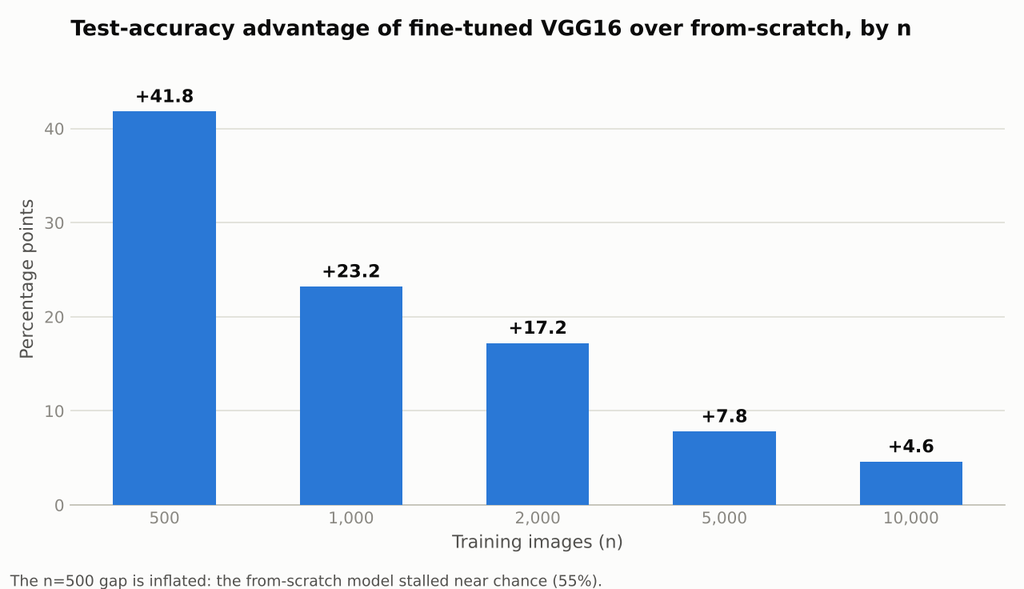

**Figure 6.** **Pretrained advantage by sample size.** Test accuracy of fine-tuned VGG16 minus from-scratch at the same n. The advantage falls steadily as the training set grows.

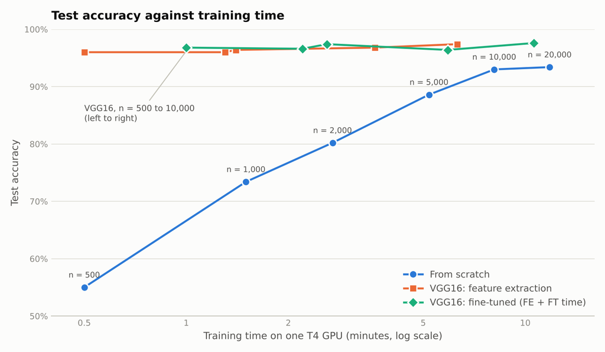

**Figure 7.** **Accuracy vs. compute.** The scratch network needs 8–12 minutes of GPU time to reach about 93%; the pretrained network is above 96% within about two minutes. (Fine-tuned time includes its feature-extraction stage; times depend on the epoch caps used.)

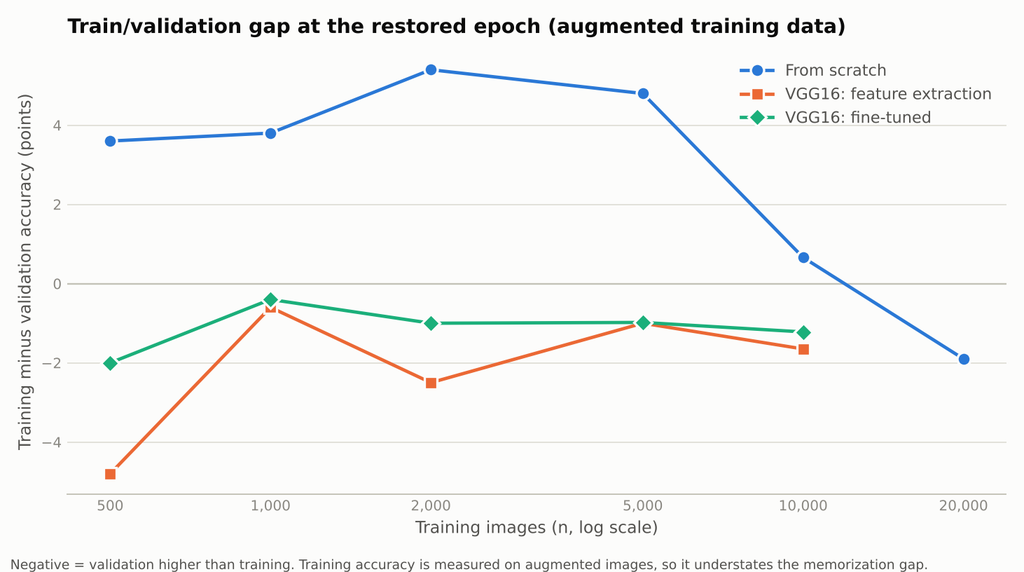

**Figure 8.** **Train/validation gap.** Where the scratch network’s training accuracy is 3.6–5.4 points above its validation accuracy (n ≤ 5,000), it is memorizing; the gap closes at 10,000 images. The pretrained networks never show a positive gap — their validation accuracy is at least their (augmented, dropout-regularized) training accuracy.

**Answer to the assignment question.** Sample size and network choice interact. With small samples (≤ 2,000 images) a from-scratch convnet overfits or fails to train and a pretrained network is far better (17–23 points on test at 1,000–2,000 images). As the sample grows, the scratch network improves steadily while the pretrained network, already near its ceiling, barely changes, so the advantage shrinks (7.8 points at 5,000 and 4.6 at 10,000). Even at 20,000 images the scratch network (93.4% test) stays about 3.4 points below fine-tuned VGG16 trained on just 500 images (96.8%).

## 8. Statistical reliability

Each accuracy is measured on 500 images, so it carries sampling error. The 95% Wilson confidence intervals in Tables 1–3 are about ±1.5 points for accuracies near 97% and ±3.5 points near 80%. This has three consequences:

- **Large effects are solid.** The gaps at 1,000 and 2,000 images (23 and 17 points) and the rise of the scratch network from 1,000 to 10,000 images (73% → 93%) are many times larger than the intervals.
- **Small effects are not.** Differences of about a point among pretrained configurations (feature extraction vs. fine-tuning, n = 500 vs. 10,000) are inside the intervals and should not be read as a ranking. One image is 0.2 points.
- **Borderline comparisons.** Fine-tuned VGG16 at 500 images (96.8%, CI 94.9–98.0) versus scratch at 20,000 images (93.4%, CI 90.9–95.3) are in the same direction on both test (+3.4) and validation (+3.2), but the unpaired intervals overlap slightly; the claim is that the pretrained network is *at least as good* with 40 times fewer images, not that the difference is precisely measured. Because both models are scored on the same test images the comparison is paired and therefore tighter than the intervals suggest, but per-image predictions were not saved, so a paired test (McNemar) could not be run.

## 9. Discussion and practical guidance

### Why the pretrained network wins at small n

VGG16 was trained on ImageNet, which contains many dog breeds and several cat classes, so its convolutional layers already encode the textures, shapes and body parts that separate cats from dogs. A linear-style head on those features needs only hundreds of examples. The scratch network must learn every filter from the same few images; with 500–2,000 images it either stalls (n = 500) or memorizes (training accuracy 3.6–5.4 points above validation despite augmentation and dropout, Figure 8).

### Why the advantage shrinks as n grows

More images let the scratch network learn useful filters itself: its gap between training and validation accuracy vanishes by 10,000 images and its accuracy approaches 93–95%. At that point it is limited by model size and training length rather than by data. The pretrained network has little left to gain.

### Guidance

| Labeled images available | Recommended approach | Expected test accuracy (this task) |
| --- | --- | --- |
| Up to about 2,000 | Pretrained VGG16, feature extraction (fine-tune if time allows) | ≈ 96–97% |
| About 5,000 | Pretrained VGG16; scratch is 8 points lower | ≈ 96–97% vs. ≈ 89% scratch |
| 10,000–20,000 | Pretrained still higher; scratch becomes competitive | ≈ 97% vs. ≈ 93% scratch |

Applies to a task close to ImageNet content, as here. For images very different from ImageNet (for example medical or satellite images) the advantage of ImageNet weights may be smaller; that was not tested.

## 10. Limitations

- **Single run per configuration** (seed 123). Run-to-run variation was not measured, so small differences are not reliable.
- **Validation set reused.** It drove early stopping, learning-rate reduction and the choice of the best run; validation accuracy is therefore somewhat optimistic. Test accuracy was not used for any decision.
- **Scratch n = 500 failed to train** (56% validation) and was stopped early; the +41.8-point gap at that size overstates a typical difference. The scratch runs at 5,000, 10,000 and 20,000 images stopped at their epoch cap; they were still improving slowly and could gain a little with more epochs.
- **No per-size tuning.** The scratch architecture and hyperparameters were not re-tuned for each sample size, and the pretrained sweep used smaller epoch caps (12 and 8) than Q1–Q2 (15 and 10); several of those runs ended at the cap.
- **Not run:** scratch with all 24,000 training-pool images; pretrained at 20,000 images; other pretrained backbones or other tasks.
- **Timing.** Minutes depend on the epoch caps and on the shared Kaggle GPU; they indicate order of magnitude only.

## 11. Conclusions

1. Training from scratch on 1,000 images gives 79.2% validation / 73.4% test (Q1); 5,000 images give 88.0% / 88.6% (Q2); the best from-scratch size tested is 20,000 images (95.2% / 93.4%), with 10,000 almost as good (Q3).
2. A pretrained VGG16 reaches 99.4% validation / 96.6% test with 1,000 images and stays at 96–98% test for every size from 500 to 10,000 images (Q4).
3. Relationship: the smaller the sample, the larger the benefit of a pretrained network; the benefit shrinks from 23 points (1,000 images) to under 5 points (10,000) as the scratch network catches up, and pretrained transfer is at least as good as scratch even at 20,000 images.
4. For this problem, a pretrained network with 1,000 labeled images is the efficient choice: higher accuracy than any from-scratch model, about two minutes of training and a twentieth of the data.

## Appendix A. Reproducibility and configuration

- Software: TensorFlow 2.20.0, Keras 3.13.2, Python on Kaggle; two Tesla T4 GPUs (the first was used). Seed 123 for data split and model initialization.
- Data: Kaggle Dogs vs. Cats `train.zip` (25,000 images). Validation and test sets: 250 cats + 250 dogs each, fixed. Training subsets are symbolic links into the pool.
- Files: `Assignment2_Convnets.ipynb` (code and outputs), its `.html` and `.pdf` exports, `results.csv` (all 16 runs) and the figures.
- Learning-curve figures in this report were redrawn at higher resolution from the per-epoch values printed in the notebook’s training logs; the final accuracies were checked against `results.csv` for all 16 runs.

## Appendix B. Original notebook figures

The graphs below are exactly as produced by the notebook cells in Kaggle (Figures B1–B6 are the per-run learning curves of Q1 and Q2; B7 is the summary chart).

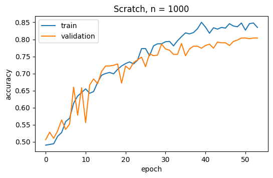

**B1.** Scratch, n = 1,000 (Q1): accuracy curves

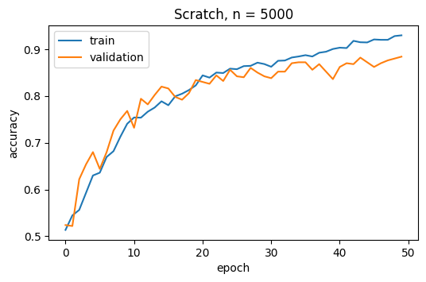

**B2.** Scratch, n = 5,000 (Q2): accuracy curves

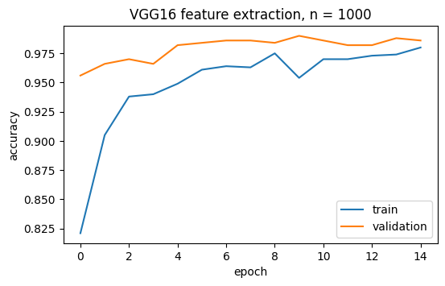

**B3.** VGG16, n = 1,000: stage 1 (feature extraction) accuracy

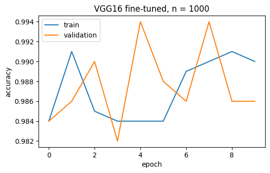

**B4.** VGG16, n = 1,000: stage 2 (fine-tuning) accuracy

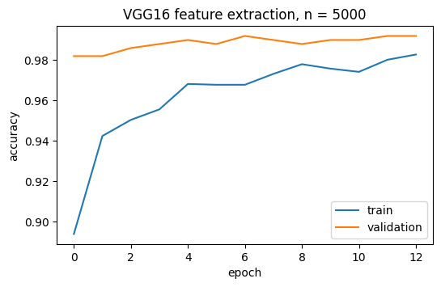

**B5.** VGG16, n = 5,000: stage 1 (feature extraction) accuracy

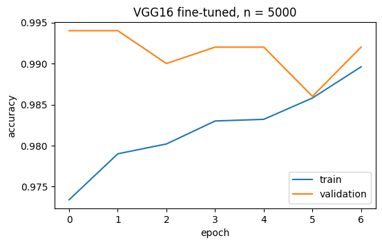

**B6.** VGG16, n = 5,000: stage 2 (fine-tuning) accuracy

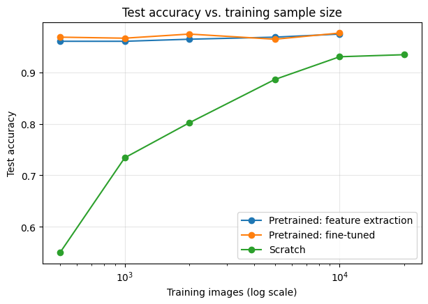

**B7.** Summary chart: test accuracy vs training size

## Appendix C. All results

Table C1. All 16 runs (also in results.csv)

| Approach | Question | n | Epochs run | Val acc | Test acc | Test 95% CI (%) | Minutes |
| --- | --- | --- | --- | --- | --- | --- | --- |
| Scratch | Q3 | 500 | 30 | 56.0% | 55.0% | 50.6–59.3 | 0.5 |
| Scratch | Q1 | 1,000 | 54 | 79.2% | 73.4% | 69.4–77.1 | 1.5 |
| Scratch | Q3 | 2,000 | 59 | 81.4% | 80.2% | 76.5–83.5 | 2.7 |
| Scratch | Q2 | 5,000 | 50 | 88.0% | 88.6% | 85.5–91.1 | 5.2 |
| Scratch | Q3 | 10,000 | 40 | 93.0% | 93.0% | 90.4–94.9 | 8.1 |
| Scratch | Q3 | 20,000 | 30 | 95.2% | 93.4% | 90.9–95.3 | 11.8 |
| Pretrained: feature extraction | Q3 | 500 | 9 | 97.6% | 96.0% | 93.9–97.4 | 0.5 |
| Pretrained: feature extraction | Q1 | 1,000 | 15 | 98.6% | 96.0% | 93.9–97.4 | 1.3 |
| Pretrained: feature extraction | Q3 | 2,000 | 11 | 99.0% | 96.4% | 94.4–97.7 | 1.4 |
| Pretrained: feature extraction | Q2 | 5,000 | 13 | 98.8% | 96.8% | 94.9–98.0 | 3.6 |
| Pretrained: feature extraction | Q3 | 10,000 | 12 | 99.2% | 97.4% | 95.6–98.5 | 6.3 |
| Pretrained: fine-tuned | Q3 | 500 | 8 | 98.4% | 96.8% | 94.9–98.0 | 0.5 |
| Pretrained: fine-tuned | Q1 | 1,000 | 10 | 99.4% | 96.6% | 94.6–97.9 | 0.9 |
| Pretrained: fine-tuned | Q3 | 2,000 | 8 | 99.2% | 97.4% | 95.6–98.5 | 1.2 |
| Pretrained: fine-tuned | Q2 | 5,000 | 7 | 99.0% | 96.4% | 94.4–97.7 | 2.3 |
| Pretrained: fine-tuned | Q3 | 10,000 | 7 | 99.2% | 97.6% | 95.9–98.6 | 4.3 |

Confidence intervals are 95% Wilson intervals for a proportion measured on 500 test images.